# Calum`s spatial error model Kluane Low

Jakob J. Assmann

2024-03-01

## Set up R session

```r
knitr::opts_chunk$set(echo = TRUE)
# Dependencies
library(tidyverse)
library(sp)
library(gstat)
library(spdep)
library(spatialreg)
library(ggplot2)
library(cowplot)
library(colorspace)
library(pbapply)
library(broom)
library(kableExtra)

# Load data
kl_data <- read_csv("s2-kl-smooth-joined.csv", show_col_types = FALSE) %>%
  st_as_sf(coords = c('X', 'Y'), crs = 32608) %>%
  group_by(id) %>%
  filter(row_number() == 7) %>%
  ungroup()
```

## Data overview

The data set consist of the **center coordinates for 660 pixels** arranged in a grid. Each pixel is 10 m x 10 m. The cooridnates are projected in UTM zone 8N (a planar metric projection), distances are in m.

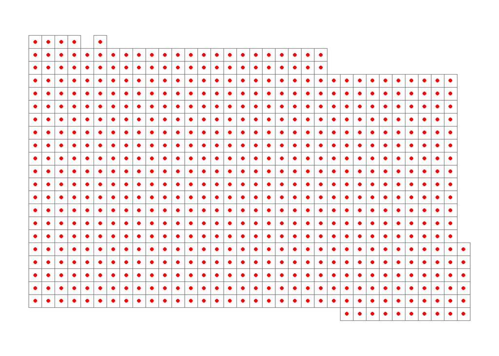

```r
ggplot() +
  geom_sf(data = st_geometry(kl_data), col = "red") +
  geom_sf(data = st_geometry(kl_data) %>% st_buffer(5, endCapStyle = "SQUARE"),
          fill = NA) +
  theme_map()
```

Each pixel has two attributes of interest:

1. peak-seasons greenness (NDVI)

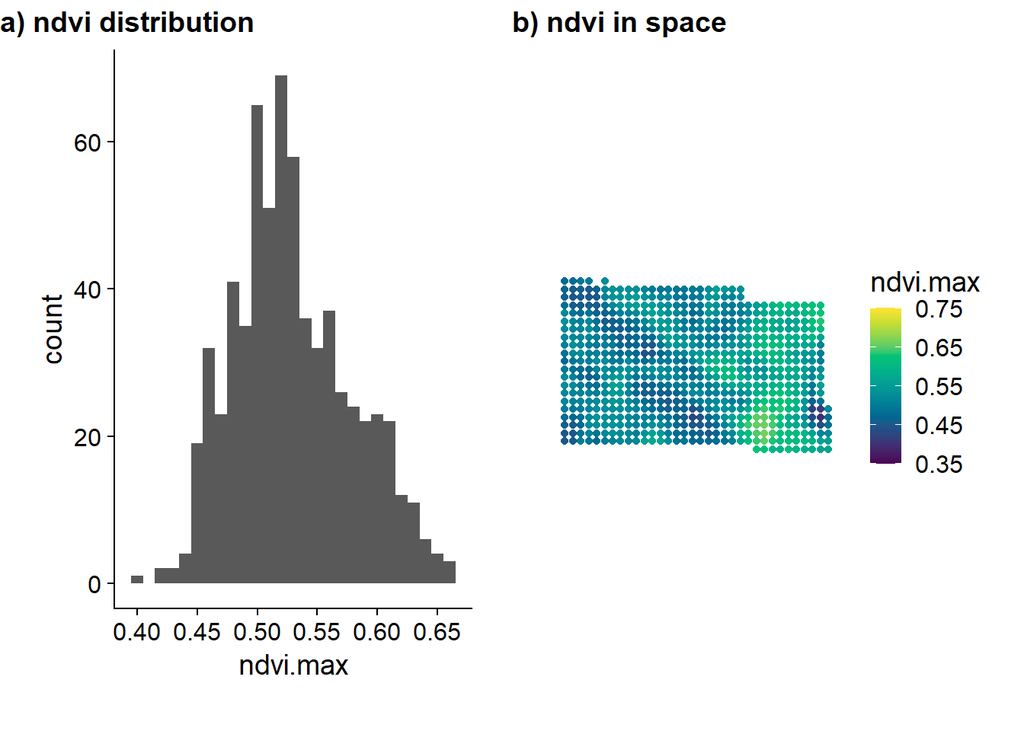

```r
plot_grid(
  ggplot(st_drop_geometry(kl_data)) +
    geom_histogram(aes(x = ndvi.max), binwidth = 0.01) +
    scale_x_continuous(breaks = seq(0.3, 0.7, 0.05)) +
    theme_cowplot(),
  ggplot() +
    geom_sf(data = kl_data, mapping = aes(colour = ndvi.max)) +
    scale_colour_continuous_sequential(palette = "viridis", rev = F,
                                       limits = c(0.35, 0.75)) +
    theme_map(),
  labels = c("a) ndvi distribution", "b) ndvi in space"),
  hjust = 0,
  scale = 0.9
)
```

2. snow persistence across the season (snow.auc)

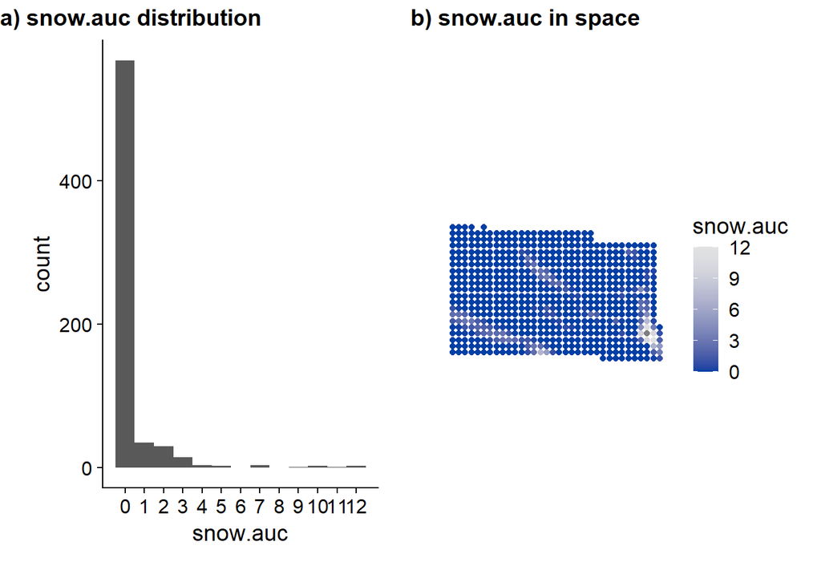

```r
plot_grid(
  ggplot(st_drop_geometry(kl_data)) +
    geom_histogram(aes(x = snow.auc), binwidth = 1) +
    scale_x_continuous(breaks = seq(0, 12, 1)) +
    theme_cowplot(),
  ggplot() +
    geom_sf(data = kl_data, mapping = aes(colour = snow.auc)) +
    scale_colour_continuous_sequential(rev = F,
                                       limits = c(0,12)) +
    theme_map(),
  labels = c("a) snow.auc distribution", "b) snow.auc in space"),
  hjust = 0,
  scale = 0.9
)
```

## Hypothesis

We predict that a higher snow presistance (snow.auc) is associated with a lower peak season greenness (ndvi.max):

ndvi.max ~ (-a) * snow.auc + c

Here is a simple linear model fit:

```r
kl_lm <- lm(ndvi.max ~ snow.auc, data = kl_data)
tidy(kl_lm)
```

```
## # A tibble: 2 × 5
##   term        estimate std.error statistic  p.value
##   <chr>          <dbl>     <dbl>     <dbl>    <dbl>
## 1 (Intercept)  0.531     0.00197    270.   0
## 2 snow.auc    -0.00542   0.00144     -3.76 0.000185
```

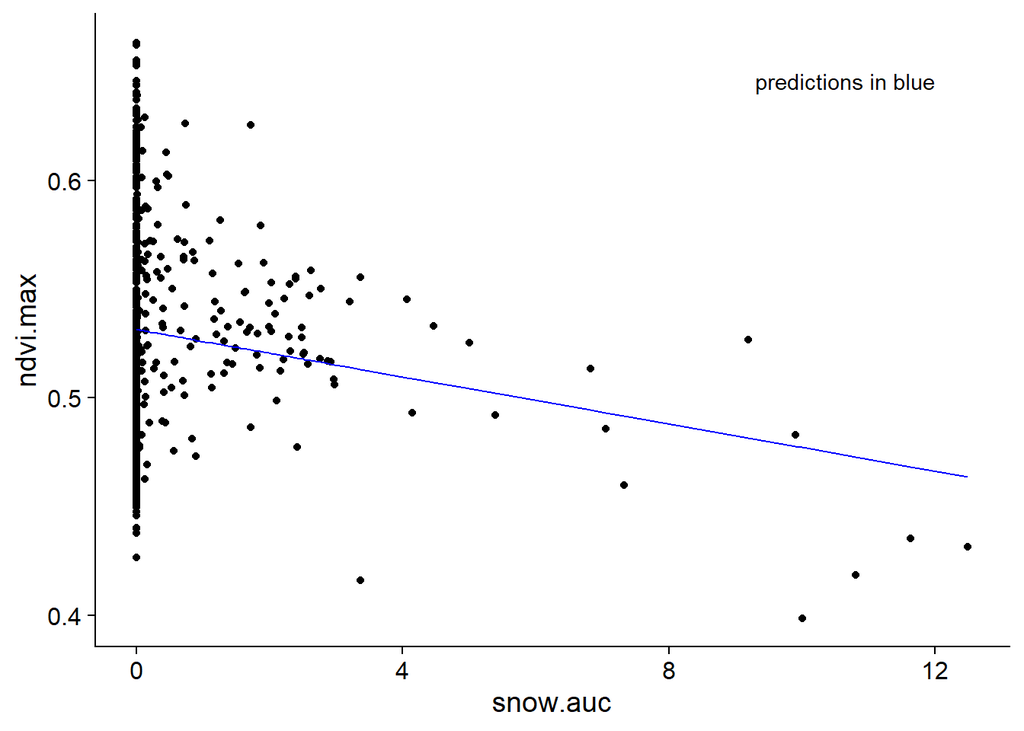

```r
ggplot(kl_data, aes(x = snow.auc, y = ndvi.max)) +
  geom_point() +
  geom_line(aes(x = snow.auc, y = fitted(kl_lm)), colour = "blue")  +
  annotate("text", x = 12, y = 0.65, hjust = 1, vjust = 1,
           label = "predictions in blue") +
  theme_cowplot()
```

However, we know that there are many other factors that are influencing peak season greenness (ndvi.max), for example nutrient clusters etc… We haven’t measured these, but they are also not of interest to us.We therefore chose a spatial error model to account for them implicitly and to avoid pseudo replication.

## Spatial autocoreelation in the response variable

Here is a variogram for the ndv.max and the residuals for the linera model with a spherical model fitted.

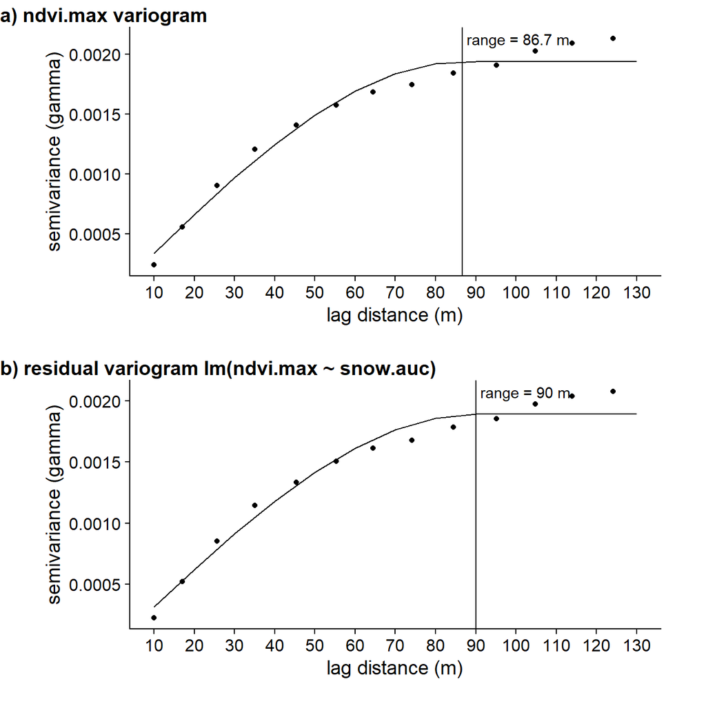

```r
# Fit variogram ndvi
vario_ndvi.max <- as_Spatial(kl_data) %>% as("SpatialPointsDataFrame") %>%
  variogram(ndvi.max ~ 1, data = ., cutoff = 130, width = 10)
vario_ndvi.max_fit <- fit.variogram(vario_ndvi.max, model = vgm(model = "Sph"))
# Fit variogram residuals
vario_resid <- kl_data %>% mutate(resid = kl_lm$residuals) %>%
  as_Spatial() %>%
  as("SpatialPointsDataFrame") %>%
  variogram(resid ~ 1, data = ., cutoff = 130, width = 10)
vario_resid_fit <- fit.variogram(vario_resid, model = vgm(model = "Sph"))

# Visualise results
plot_grid(
ggplot(vario_ndvi.max) +
  geom_point(aes(x = dist, y = gamma)) +
  geom_line(aes(x = dist, y = gamma),
            data = variogramLine(vario_ndvi.max_fit,
                                 dist_vector = seq(10,130,10))) +
  geom_vline(xintercept = vario_ndvi.max_fit$range) +
  annotate("text", x = vario_ndvi.max_fit$range, y  = Inf,
           label = paste0(" range = ", round(vario_ndvi.max_fit$range, 1), " m"),
           hjust = 0, vjust = 1.5) +
  scale_x_continuous(limits = c(10, 130), breaks = seq(10,130,10)) +
  labs(x = "lag distance (m)", y = "semivariance (gamma)") +
  theme_cowplot(),
ggplot(vario_resid) +
  geom_point(aes(x = dist, y = gamma)) +
  geom_line(aes(x = dist, y = gamma),
            data = variogramLine(vario_resid_fit,
                                 dist_vector = seq(10,130,10))) +
  geom_vline(xintercept = vario_resid_fit$range) +
  annotate("text", x = vario_resid_fit$range, y  = Inf,
           label = paste0(" range = ", round(vario_resid_fit$range, 1), " m"),
           hjust = 0, vjust = 1.5) +
  scale_x_continuous(limits = c(10, 130), breaks = seq(10,130,10)) +
  labs(x = "lag distance (m)", y = "semivariance (gamma)") +
  theme_cowplot(),
  labels = c("a) ndvi.max variogram", "b) residual variogram lm(ndvi.max ~ snow.auc)"),
  hjust = 0,
  scale = 0.9,
  nrow = 2,
  ncol = 1
)
```

Arguably, the both fits are a bit crude as the data does not seem to fully level off beyond the largest lag distance assessed (130 m = 1/3 of diagonal of dataset). However,the range of 87 m (90 m) provides a good starting point for the choice of the neighbourhood size.

To further inform the choice of the neighbourhood size, we caluclated Moran’s I for the same lag distances as shown in the variogram (here upper ends of neighbourhood).

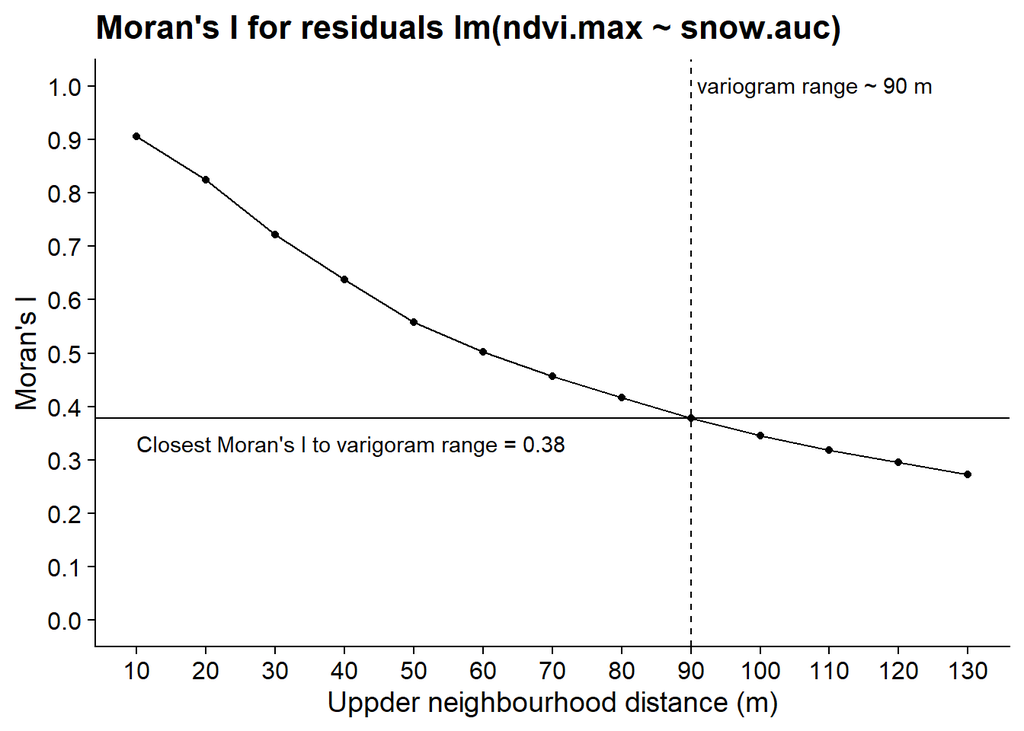

```r
morans_i <- seq(10, 130, 10) %>%
  pblapply(function(x){
    kl_nb <- dnearneigh(kl_data, d1 = 0, d2 = x)
    kl_lb <- nb2listw(kl_nb, style = "W", zero.policy = TRUE)
    moran <- moran.mc(kl_lm$residuals, kl_lb, nsim = 999, zero.policy = TRUE)
    data.frame(dist = x,
               morans_i = moran$statistic)
  }) %>%
  bind_rows()
ggplot(data = morans_i, aes(x = dist, y = morans_i)) +
  geom_point() +
  geom_line() +
  geom_vline(xintercept = 90, linetype = "dashed") +
  annotate("text", x = 90, y = Inf, label = " variogram range ~ 90 m",
           hjust = 0, vjust = 2) +
  geom_hline(yintercept = morans_i[morans_i$dist == 90,"morans_i"]) +
  annotate("text", x = 10, y = morans_i[morans_i$dist == 90,"morans_i"],
           label = paste0("Closest Moran's I to varigoram range = ",
                          round(morans_i[morans_i$dist == 90,"morans_i"],2)),
           hjust = 0, vjust = 2) +
  scale_x_continuous(limits = c(10,130), breaks = seq(10,130,10)) +
  scale_y_continuous(limits = c(0,1), breaks = seq(0,1,0.1)) +
  labs(x = "Uppder neighbourhood distance (m)",
       y = "Moran's I",
       title = "Moran's I for residuals lm(ndvi.max ~ snow.auc)") +
  theme_cowplot()
```

A Moran’s I value for varigoram range of 0.38 seems like a reasonable value, suggesting that there is a moderate level of autocorrelation at this neighborhood distance.

Let’s visualise the residuals in space with a 90 m neigbhourhood as a reference:

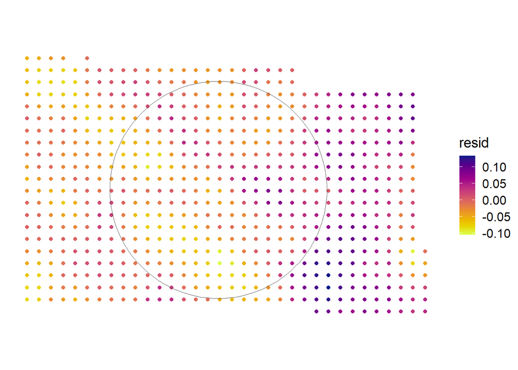

```r
ggplot() +
  geom_sf(data = kl_data %>% mutate(resid = kl_lm$residuals),
          aes(colour = resid)) +
  geom_sf(data = kl_data %>%
                        summarize() %>%
                        st_centroid() %>%
                        st_buffer(90), fill = NA) +
  scale_color_continuous_sequential(palette = "plasma") +
  theme_map()
```

The neighbourhood seems rather large, but hen it also seems to match the concentration of residuals on the lefthand side, where there would be a high reisk of pesudo- replication.

## Fitting a spatial error model with a 90 m neighbourhood

We fit a simple spatial error model using the `errorsarlm()` function from the `spatialreg` package.

```r
# Define neighbourhood 90
kl_lw <- dnearneigh(kl_data, d1 = 0, d2 = 90) %>%
  nb2listw(style = "W", zero.policy = TRUE)
# Fit model
kl_sem <- errorsarlm(ndvi.max ~ snow.auc,
                            data = kl_data,
                            listw = kl_lw,
                            zero.policy = TRUE)
```

Model coefficients

```r
# Summary
tidy(kl_sem) %>% kbl() %>% kable_classic(full_width = F, html_font = "Cambria")
```

| term | estimate | std.error | statistic | p.value |
| --- | --- | --- | --- | --- |
| (Intercept) | 0.5070479 | 0.0615985 | 8.231493 | 0 |
| snow.auc | -0.0092349 | 0.0011494 | -8.034585 | 0 |
| lambda | 0.9767295 | 0.0159619 | 61.191407 | 0 |

Model statistics

```r
# Summary
glance(kl_sem) %>% kbl() %>% kable_classic(full_width = F, html_font = "Cambria")
```

| r.squared | AIC | BIC | deviance | logLik | nobs |
| --- | --- | --- | --- | --- | --- |
| 0.4382793 | -2467.127 | -2449.158 | 0.8939786 | 1237.564 | 660 |

Compare to AIC of simple linear model (no spatial error): -2119.4334754.

The AIC of the spatial error model is lower, suggesting that it provides a better fit.

## Spatial error model vis

```
## This method assumes the response is known - see manual page
```

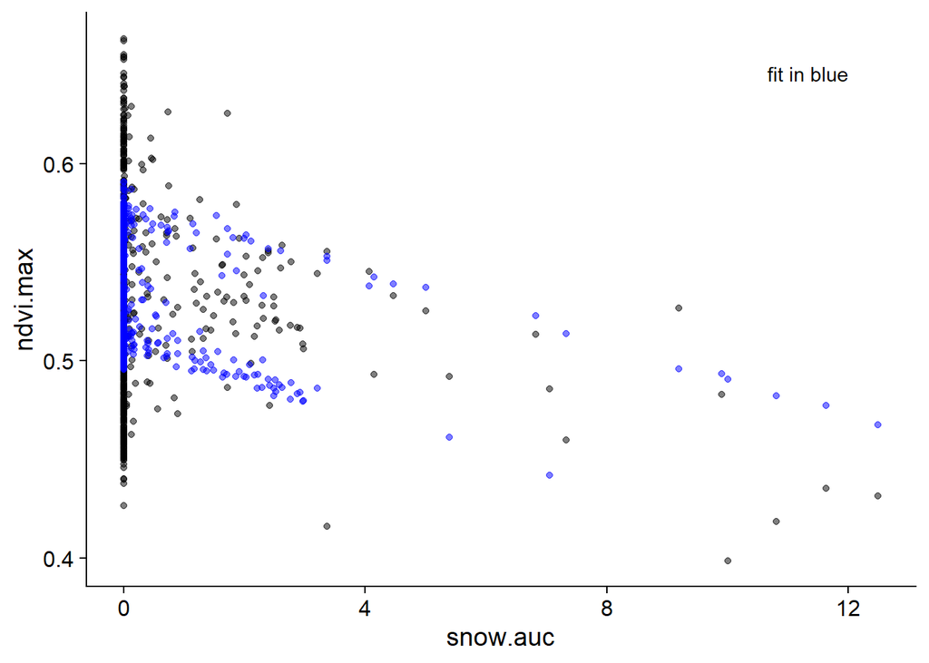

```r
ggplot(kl_data %>% mutate(fit = fitted(kl_sem))) +
  geom_point(aes(x = snow.auc, y = ndvi.max), alpha = 0.5) +
  geom_point(aes(x = snow.auc, y = fit), colour = "blue", alpha = 0.5) +
  annotate("text", x = 12, y = 0.65, hjust = 1, vjust = 1,
           label = "fit in blue") +
    theme_cowplot()
```

The spatial error models seems to produce two groupings in the data based on the intercept, this seems logical, considering the distribution of residuals and neighbourhoods size as discussed earlier (see spatial figure). Let’s see whether there is still auto correlation in the residuals of the sem.

Moran’s I for 90 m neigbhourhoods:

```r
moran.mc(kl_sem$residuals, kl_lw, nsim = 999, zero.policy = TRUE)
```

```
##
##  Monte-Carlo simulation of Moran I
##
## data:  kl_sem$residuals
## weights: kl_lw
## number of simulations + 1: 1000
##
## statistic = -0.00080648, observed rank = 651, p-value = 0.349
## alternative hypothesis: greater
```

The spatial error model seems to have successfully accounted for the auto correlation at the chosen neighbourhood size.

How does it look like for smaller neighbourhoods?

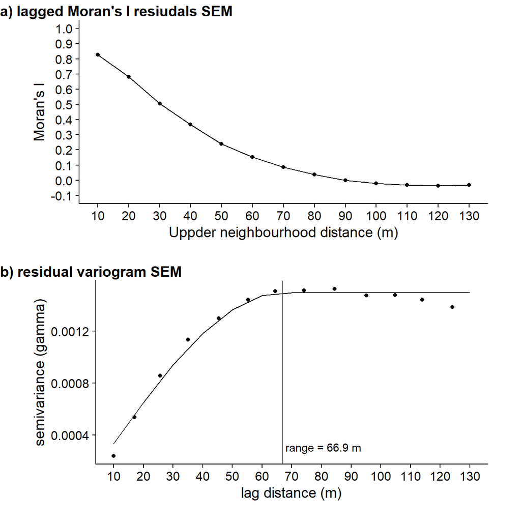

```r
# Moran's I for lagged sitances
morans_i_sem <- seq(10, 130, 10) %>%
  pblapply(function(x){
    kl_nb <- dnearneigh(kl_data, d1 = 0, d2 = x)
    kl_lb <- nb2listw(kl_nb, style = "W", zero.policy = TRUE)
    moran <- moran.mc(kl_sem$residuals, kl_lb, nsim = 999, zero.policy = TRUE)
    data.frame(dist = x,
               morans_i = moran$statistic)
  }) %>%
  bind_rows()

# Variogram
# Fit variogram residuals
vario_resid_sem <- kl_data %>% mutate(resid = kl_sem$residuals) %>%
  as_Spatial() %>%
  as("SpatialPointsDataFrame") %>%
  variogram(resid ~ 1, data = ., cutoff = 130, width = 10)
vario_resid_sem_fit <- fit.variogram(vario_resid_sem, model = vgm(model = "Sph"))

# Visualise results
plot_grid(
  ggplot(data = morans_i_sem, aes(x = dist, y = morans_i)) +
  geom_point() +
  geom_line() +
  scale_x_continuous(limits = c(10,130), breaks = seq(10,130,10)) +
  scale_y_continuous(limits = c(-0.1,1), breaks = seq(-0.1,1,0.1)) +
  labs(x = "Uppder neighbourhood distance (m)",
       y = "Moran's I") +
  theme_cowplot(),
ggplot(vario_resid_sem) +
  geom_point(aes(x = dist, y = gamma)) +
  geom_line(aes(x = dist, y = gamma),
            data = variogramLine(vario_resid_sem_fit,
                                 dist_vector = seq(10,130,10))) +
  geom_vline(xintercept = vario_resid_sem_fit$range) +
  annotate("text", x = vario_resid_sem_fit$range, y  = -Inf,
           label = paste0(" range = ", round(vario_resid_sem_fit$range, 1), " m"),
           hjust = 0, vjust = -1.5) +
  scale_x_continuous(limits = c(10, 130), breaks = seq(10,130,10)) +
  labs(x = "lag distance (m)", y = "semivariance (gamma)") +
  theme_cowplot(),
  labels = c("a) lagged Moran's I resiudals SEM", "b) residual variogram SEM"),
  hjust = 0,
  scale = 0.9,
  nrow = 2,
  ncol = 1
)
```

And here is how the residuals of the spatial error model are distributed in space:

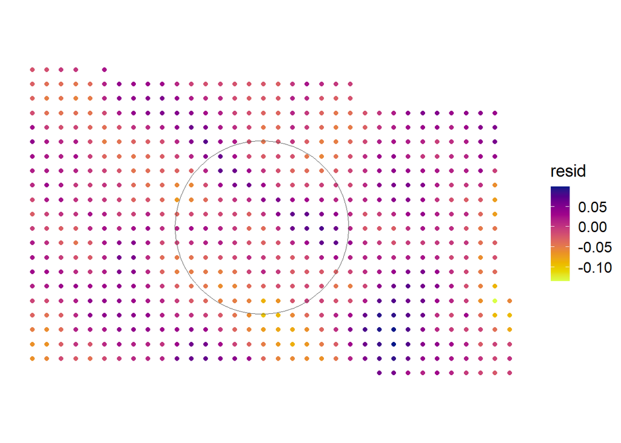

```r
ggplot() +
  geom_sf(data = kl_data %>% mutate(resid = residuals(kl_sem)),
          mapping = aes(colour = resid)) +
  geom_sf(data = kl_data %>%
                        summarize() %>%
                        st_centroid() %>%
                        st_buffer(60), fill = NA) +
    scale_color_continuous_sequential(palette = "plasma") +
    theme_map()
```

It looks like there is auto correlations at two different lag sizes. Once at 90 m as accounted for in the first SEM and once at a shorter distance (around 60 m?).

Let’s try that neighbourhood distance as well.

## Fitting the spatial error model with a 60 m neighbourhood

```r
# Define neighbourhood 60
kl_lw_60 <- dnearneigh(kl_data, d1 = 0, d2 = 60) %>%
  nb2listw(style = "W", zero.policy = TRUE)
# Fit model
kl_sem_60 <- errorsarlm(ndvi.max ~ snow.auc,
                            data = kl_data,
                            listw = kl_lw_60,
                            zero.policy = TRUE)
```

Model coefficients

```r
# Summary
tidy(kl_sem_60) %>% kbl() %>% kable_classic(full_width = F, html_font = "Cambria")
```

| term | estimate | std.error | statistic | p.value |
| --- | --- | --- | --- | --- |
| (Intercept) | 0.4996736 | 0.0788251 | 6.339015 | 0 |
| snow.auc | -0.0074486 | 0.0010413 | -7.153123 | 0 |
| lambda | 0.9841555 | 0.0106614 | 92.309863 | 0 |

Model statistics

```r
# Summary
glance(kl_sem_60) %>% kbl() %>% kable_classic(full_width = F, html_font = "Cambria")
```

| r.squared | AIC | BIC | deviance | logLik | nobs |
| --- | --- | --- | --- | --- | --- |
| 0.5785726 | -2638.808 | -2620.839 | 0.6793656 | 1323.404 | 660 |

Compare to AIC of simple linear model (no spatial error): -2119.4334754. And 90 m neighbourhood: -2467.1274463.

The AIC of the 60 m spatial error model is lower than both, suggesting that it provides a better fit.

## Spatial error model vis

```
## This method assumes the response is known - see manual page
```

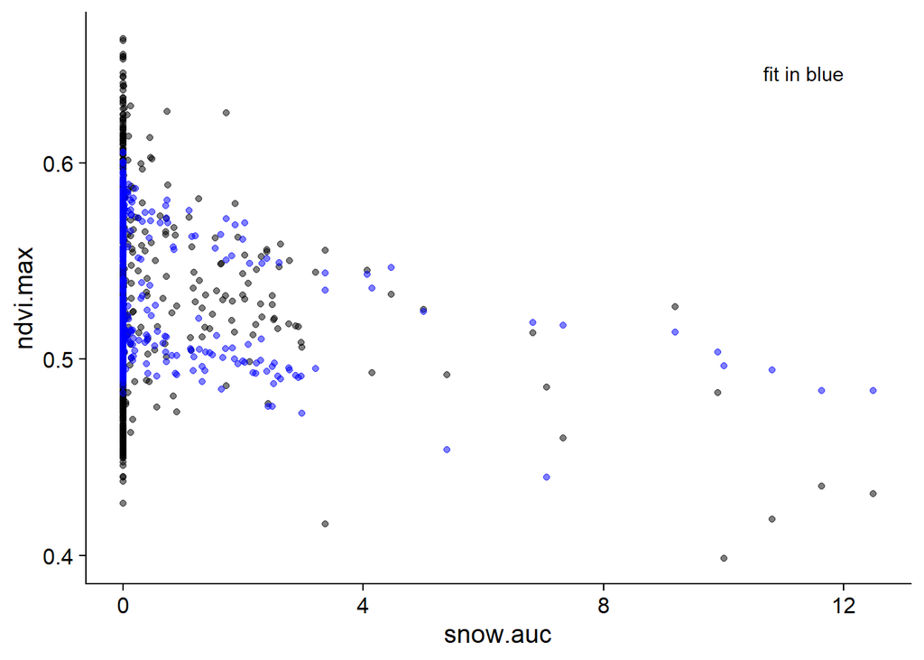

```r
ggplot(kl_data %>% mutate(fit = fitted(kl_sem_60))) +
  geom_point(aes(x = snow.auc, y = ndvi.max), alpha = 0.5) +
  geom_point(aes(x = snow.auc, y = fit), colour = "blue", alpha = 0.5)  +
  annotate("text", x = 12, y = 0.65, hjust = 1, vjust = 1,
           label = "fit in blue") +
    theme_cowplot()
```

The spatial error models seems to produce two groupings in the data based on the intercept, this seems logical, considering the distribution of residuals and neighbourhoods size as discussed earlier in the 90 m model. Let’s see whether there is still auto correlation in the residuals of the sem.

```r
moran.mc(kl_sem_60$residuals, kl_lw, nsim = 999, zero.policy = TRUE)
```

```
##
##  Monte-Carlo simulation of Moran I
##
## data:  kl_sem_60$residuals
## weights: kl_lw
## number of simulations + 1: 1000
##
## statistic = -0.0073712, observed rank = 23, p-value = 0.977
## alternative hypothesis: greater
```

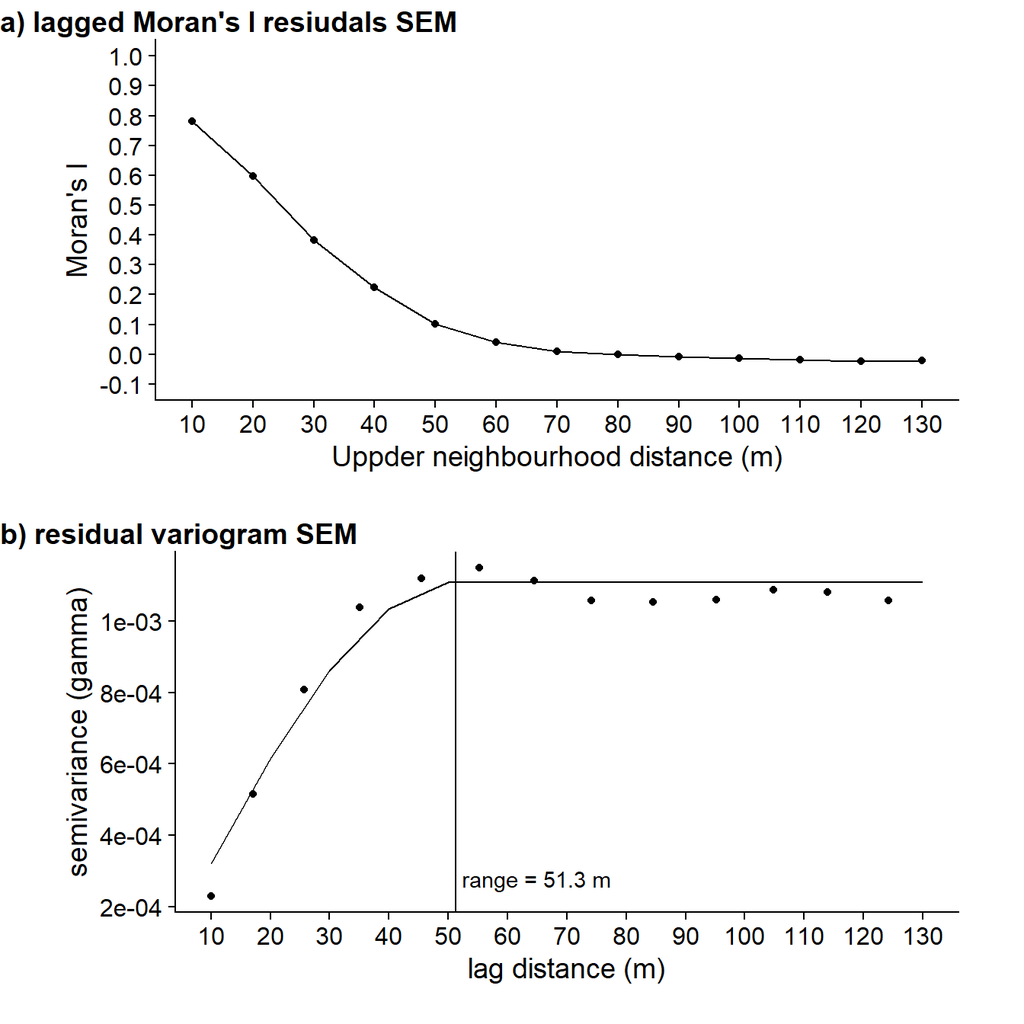

```r
# Moran's I for lagged sitances
morans_i_sem_60 <- seq(10, 130, 10) %>%
  pblapply(function(x){
    kl_nb <- dnearneigh(kl_data, d1 = 0, d2 = x)
    kl_lb <- nb2listw(kl_nb, style = "W", zero.policy = TRUE)
    moran <- moran.mc(kl_sem_60$residuals, kl_lb, nsim = 999, zero.policy = TRUE)
    data.frame(dist = x,
               morans_i = moran$statistic)
  }) %>%
  bind_rows()

# Variogram
# Fit variogram residuals
vario_resid_sem_60 <- kl_data %>% mutate(resid = kl_sem_60$residuals) %>%
  as_Spatial() %>%
  as("SpatialPointsDataFrame") %>%
  variogram(resid ~ 1, data = ., cutoff = 130, width = 10)
vario_resid_sem_fit_60 <- fit.variogram(vario_resid_sem_60, model = vgm(model = "Sph"))

# Visualise results
plot_grid(
  ggplot(data = morans_i_sem_60, aes(x = dist, y = morans_i)) +
  geom_point() +
  geom_line() +
  scale_x_continuous(limits = c(10,130), breaks = seq(10,130,10)) +
  scale_y_continuous(limits = c(-0.1,1), breaks = seq(-0.1,1,0.1)) +
  labs(x = "Uppder neighbourhood distance (m)",
       y = "Moran's I") +
  theme_cowplot(),
ggplot(vario_resid_sem_60) +
  geom_point(aes(x = dist, y = gamma)) +
  geom_line(aes(x = dist, y = gamma),
            data = variogramLine(vario_resid_sem_fit_60,
                                 dist_vector = seq(10,130,10))) +
  geom_vline(xintercept = vario_resid_sem_fit_60$range) +
  annotate("text", x = vario_resid_sem_fit_60$range, y  = -Inf,
           label = paste0(" range = ", round(vario_resid_sem_fit_60$range, 1), " m"),
           hjust = 0, vjust = -1.5) +
  scale_x_continuous(limits = c(10, 130), breaks = seq(10,130,10)) +
  labs(x = "lag distance (m)", y = "semivariance (gamma)") +
  theme_cowplot(),
  labels = c("a) lagged Moran's I resiudals SEM", "b) residual variogram SEM"),
  hjust = 0,
  scale = 0.9,
  nrow = 2,
  ncol = 1
)
```

And residuals plotted in space:

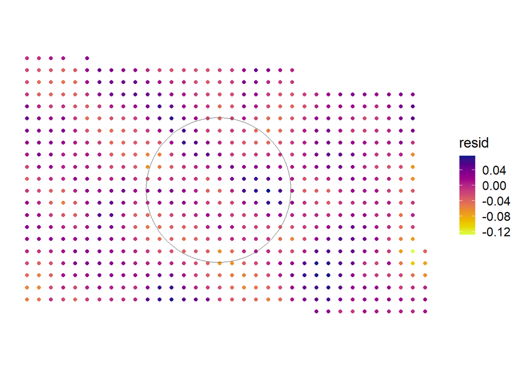

```r
ggplot() +
  geom_sf(data = kl_data %>% mutate(resid = residuals(kl_sem_60)),
          mapping = aes(colour = resid)) +
  geom_sf(data = kl_data %>%
                        summarize() %>%
                        st_centroid() %>%
                        st_buffer(60), fill = NA) +
    scale_color_continuous_sequential(palette = "plasma") +
    theme_map()
```

Again the model seems to be capturing the spatial autocorellation and perhaps, even better than the 90 m neighbourhood mpdel, but some residual autocorellation remains in the residuals.

Let’s have a a look at that:

## Fitting a spatial error model with a 30 m neighbourhood

```r
# Define neighbourhood 30
kl_lw_30 <- dnearneigh(kl_data, d1 = 0, d2 = 30) %>%
  nb2listw(style = "W", zero.policy = TRUE)
# Fit model
kl_sem_30 <- errorsarlm(ndvi.max ~ snow.auc,
                            data = kl_data,
                            listw = kl_lw_30,
                            zero.policy = TRUE)
```

Model coefficients

```r
# Summary
tidy(kl_sem_30) %>% kbl() %>% kable_classic(full_width = F, html_font = "Cambria")
```

| term | estimate | std.error | statistic | p.value |
| --- | --- | --- | --- | --- |
| (Intercept) | 0.5270246 | 0.0825000 | 6.388176 | 0 |
| snow.auc | -0.0052609 | 0.0008015 | -6.564082 | 0 |
| lambda | 0.9896781 | 0.0062112 | 159.337025 | 0 |

Model statistics

```r
# Summary
glance(kl_sem_30) %>% kbl() %>% kable_classic(full_width = F, html_font = "Cambria")
```

| r.squared | AIC | BIC | deviance | logLik | nobs |
| --- | --- | --- | --- | --- | --- |
| 0.8102847 | -3099.861 | -3081.892 | 0.3158495 | 1553.93 | 660 |

Compare to AIC of simple linear model (no spatial error): -2119.4334754. And 90 m neighbourhood: -2467.1274463. And 60 m neighbourhood: -2638.8083343.

The AIC of the 30 m spatial error model is lower than both, suggesting that it provides a better fit.

## Spatial error model vis

```
## This method assumes the response is known - see manual page
```

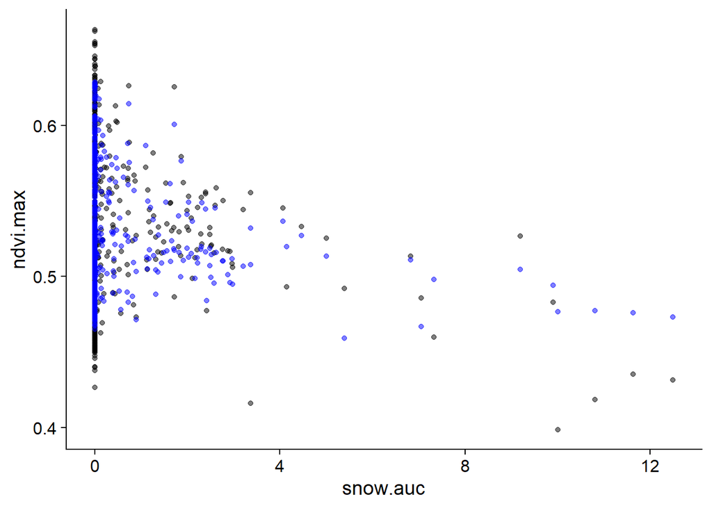

```r
ggplot(kl_data %>% mutate(fit = fitted(kl_sem_30))) +
  geom_point(aes(x = snow.auc, y = ndvi.max), alpha = 0.5) +
  geom_point(aes(x = snow.auc, y = fit), colour = "blue", alpha = 0.5) +
    theme_cowplot()
```

The spatial error models seems to produce two groupings in the data based on the intercept, this seems logical, considering the distribution of residuals and neighbourhoods size as discussed earlier in the 90 m model. Let’s see whether there is still auto correlation in the residuals of the sem.

```r
moran.mc(kl_sem_30$residuals, kl_lw, nsim = 999, zero.policy = TRUE)
```

```
##
##  Monte-Carlo simulation of Moran I
##
## data:  kl_sem_30$residuals
## weights: kl_lw
## number of simulations + 1: 1000
##
## statistic = -0.001233, observed rank = 581, p-value = 0.419
## alternative hypothesis: greater
```

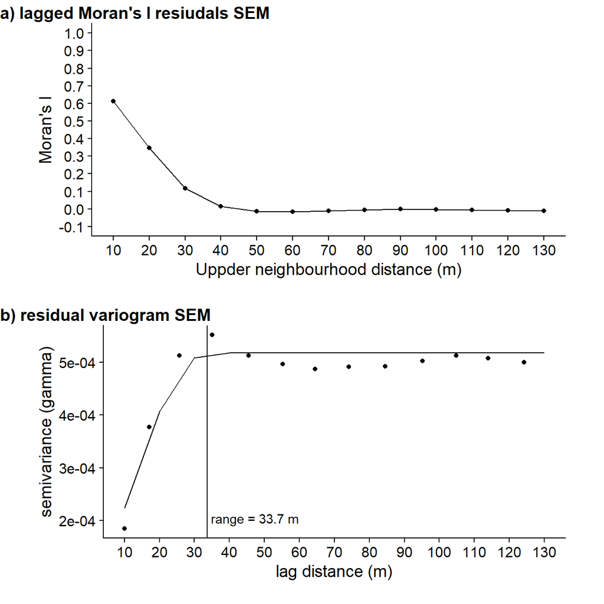

```r
# Moran's I for lagged sitances
morans_i_sem_30 <- seq(10, 130, 10) %>%
  pblapply(function(x){
    kl_nb <- dnearneigh(kl_data, d1 = 0, d2 = x)
    kl_lb <- nb2listw(kl_nb, style = "W", zero.policy = TRUE)
    moran <- moran.mc(kl_sem_30$residuals, kl_lb, nsim = 999, zero.policy = TRUE)
    data.frame(dist = x,
               morans_i = moran$statistic)
  }) %>%
  bind_rows()

# Variogram
# Fit variogram residuals
vario_resid_sem_30 <- kl_data %>% mutate(resid = kl_sem_30$residuals) %>%
  as_Spatial() %>%
  as("SpatialPointsDataFrame") %>%
  variogram(resid ~ 1, data = ., cutoff = 130, width = 10)
vario_resid_sem_fit_30 <- fit.variogram(vario_resid_sem_30, model = vgm(model = "Sph"))

# Visualise results
plot_grid(
  ggplot(data = morans_i_sem_30, aes(x = dist, y = morans_i)) +
  geom_point() +
  geom_line() +
  scale_x_continuous(limits = c(10,130), breaks = seq(10,130,10)) +
  scale_y_continuous(limits = c(-0.1,1), breaks = seq(-0.1,1,0.1)) +
  labs(x = "Uppder neighbourhood distance (m)",
       y = "Moran's I") +
  theme_cowplot(),
ggplot(vario_resid_sem_30) +
  geom_point(aes(x = dist, y = gamma)) +
  geom_line(aes(x = dist, y = gamma),
            data = variogramLine(vario_resid_sem_fit_30,
                                 dist_vector = seq(10,130,10))) +
  geom_vline(xintercept = vario_resid_sem_fit_30$range) +
  annotate("text", x = vario_resid_sem_fit_30$range, y  = -Inf,
           label = paste0(" range = ", round(vario_resid_sem_fit_30$range, 1), " m"),
           hjust = 0, vjust = -1.5) +
  scale_x_continuous(limits = c(10, 130), breaks = seq(10,130,10)) +
  labs(x = "lag distance (m)", y = "semivariance (gamma)") +
  theme_cowplot(),
  labels = c("a) lagged Moran's I resiudals SEM", "b) residual variogram SEM"),
  hjust = 0,
  scale = 0.9,
  nrow = 2,
  ncol = 1
)
```

And residuals plotted in space:

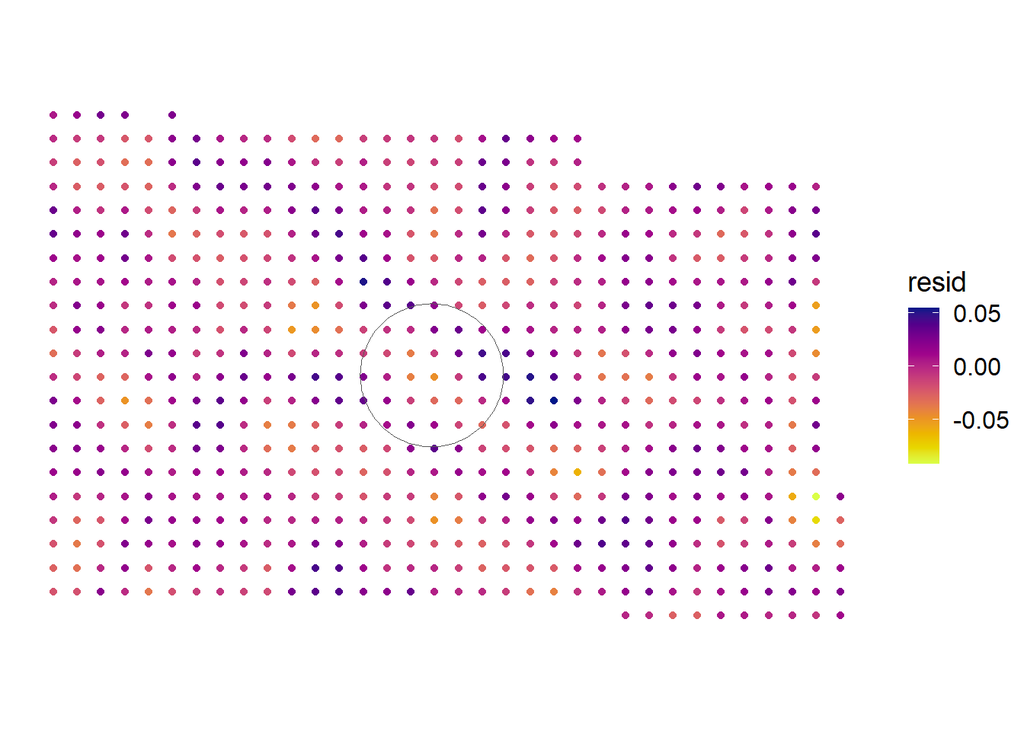

```r
ggplot() +
  geom_sf(data = kl_data %>% mutate(resid = residuals(kl_sem_30)),
          mapping = aes(colour = resid)) +
  geom_sf(data = kl_data %>%
                        summarize() %>%
                        st_centroid() %>%
                        st_buffer(30), fill = NA) +
    scale_color_continuous_sequential(palette = "plasma") +
    theme_map()
```

## Check Hausman test

(Does the spatial error model make more sense than the normal linear model):

```r
Hausman.test(kl_sem_30)
```

```
##
##  Spatial Hausman test (asymptotic)
##
## data:  NULL
## Hausman test = -9.7898, df = 2, p-value = 0.007485
```

The test is significant (p <= 0.05), suggesting that neither the OLS or the SEM are a good choice. However, I think the latter makes more sense.

## Final plot of the 30 m model

```
## This method assumes the response is known - see manual page
## This method assumes the response is known - see manual page
```

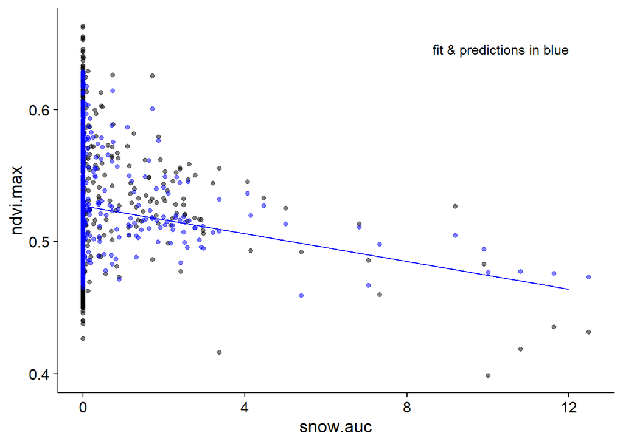

```r
ggplot() +
  geom_point(aes(x = snow.auc, y = ndvi.max), alpha = 0.5,
             data = kl_data %>% mutate(fit = fitted(kl_sem_30))) +
  geom_point(aes(x = snow.auc, y = fit), colour = "blue", alpha = 0.5,
             data = kl_data %>% mutate(fit = fitted(kl_sem_30))) +
  geom_line(aes(x = 0:12, y = kl_sem_30$coefficients[1] + (0:12 * kl_sem_30$coefficients[2])),
            col = "blue") +
  annotate("text", x = 12, y = 0.65, hjust = 1, vjust = 1,
           label = "fit & predictions in blue") +
    theme_cowplot()
```

End.